# Welcome to new grad students

## Outline

- Me
- Thoughts on "Thriving in Graduate School"
- Some big questions in ecological research today
- Some thoughts on open science

## Me

## Carl Boettiger

- 203 Wellman Hall
- @cboettig

## What I do

- Brand new ESPM faculty in "Ecoinformatics"
- Senior Fellow at Berkeley Institute for Data Science (BIDS)
- Founder / leadership team for [rOpenSci](https://ropensci.org)
- I work on: Regime shifts, optimal control in conservation & management

## What got me interested in Ecology?

## How I wound up here

- Undergraduate in Physics
- PhD in Population Biology at UC Davis ~ 5yrs
- Post-doc at UC Santa Cruz ~ 3 yrs

## Thoughts on "Thriving in Graduate School"

## Disclaimers

- non-significant sample size
- campus & discipline-specific differences

## My experience

- not necessarily representative
- my experimental control

## explore new things, other research groups

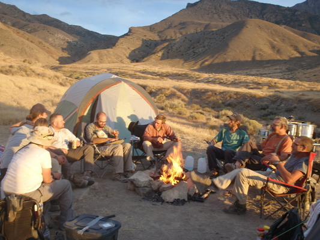

## try things that fail

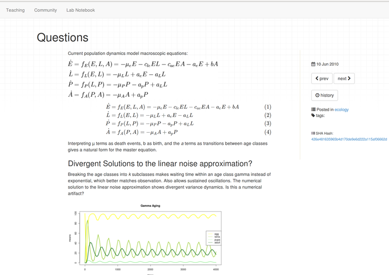

## Travel & attend conferences

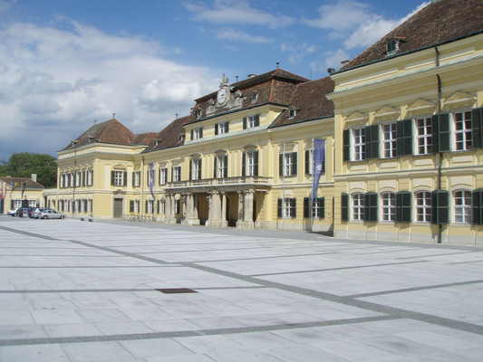

## Have fun

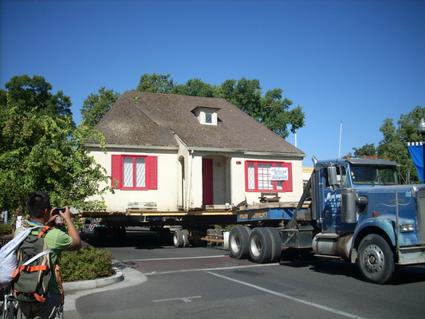

## Have fun

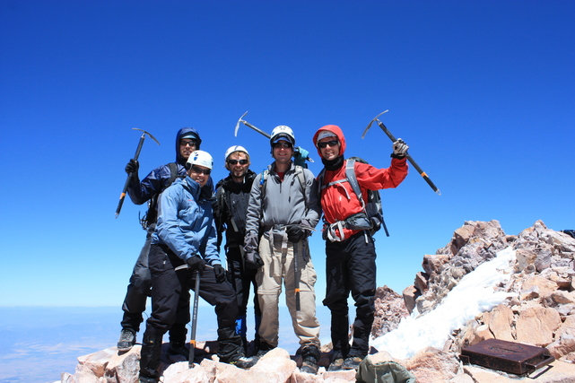

## One piece of pratical advice: try twitter for science

[figure not shown]

## Big questions in ecological research today

## Big questions in ecological research today

If you want to learn more about what I'm interested, come to my seminar – later today!

## Big questions in ecological research today

Otherwise, I'm not going to say what I think are the big questions

## Big questions in ecological research today

So that you come to my seminar?

## Big questions in ecological research today

No. Because I think Ecology is not a field of "1 degree" questions.

## Open Science

## Open Science

- I keep an [Open Lab Notebook](https://www.carlboettiger.info/2012/09/28/Welcome-to-my-lab-notebook.html)
- I'm interested in publication of data, scripts, and software (interviews)
- I hold some crazy ideas about the future of scientific publishing